# 10.0 Portfolio assignment 10

15 min: Perform a bivariate analysis (Pearson correlation and scatter plot) on at least 1 combination of 2 columns with numeric data in the dataset that you chose in portfolio assignment 4. Does the correlation and scatter plot match your expectations? Add your answer to your notebook. Commit the Notebook to your portfolio when you're finished.

[figure not shown]

```python
import pandas as pd
import seaborn as sns

chess = pd.read_csv("../assets/chess.csv", sep=',')

# Create a column based on (rating white + rating black)
chess['combined_rating'] = chess['white_rating'] + chess['black_rating']
```

## 10.1 Bivariate analysis (Numerical vs Numerical)

### 10.1.1 Correlaties

De kolommen waar ik voor gekozen heb is combined_rating (rating_white + rating_black) en opening_ply (het aantal theoretische zetten van zwart en wit). Deze hebben namelijk de sterkste positieve correlatie.

```python
chess[['combined_rating', 'opening_ply', 'turns']].corr().style.background_gradient(cmap='coolwarm', axis=None).format(precision=2)
```

|  | combined_rating | opening_ply | turns |
| --- | --- | --- | --- |
| combined_rating | 1.00 | 0.29 | 0.16 |
| opening_ply | 0.29 | 1.00 | 0.06 |
| turns | 0.16 | 0.06 | 1.00 |

### 10.1.2 Scatterplot correlatie

De sterkste positieve correlatie is vervolgens gevisualiseerd in een scatterplot. Hier in is te zien dat spelers met een lagere gecomineerde rating vaak beginnen met minder zetten uit theorie. Naar mate hoe hoger de gecombineerde rating is er te zien hoe er meer zetten vanuit theorie worden gespeeld. Dit is ook het verwachtte resultaat.

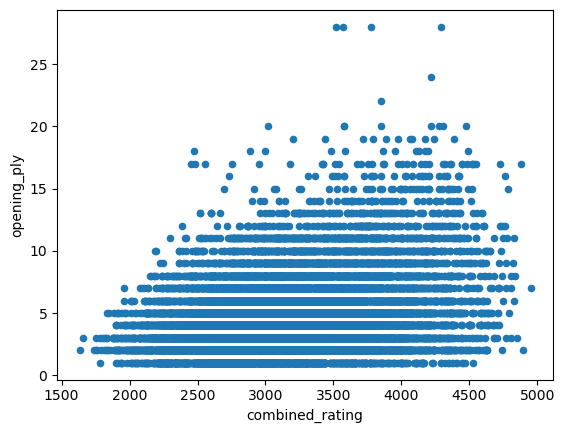

```python
chess.plot(kind='scatter', x='combined_rating', y='opening_ply')
```